# QM 2024 Week 1: Getting Started with R

## Data Structures

What kind of data can I store in R? Different types of objects that can contain different types and sets of data:

- **Scalar**: numbers, characters, logical values
- **Vector**: sets of scalars (thus, numbers, characters, logical)
- **Matrix**: two-dimensional set of scalars of same type
- **Data frame**: collections of vectors of (possibly) different types
- **Array**: multidimensional set of scalars of same type
- **List**: combinations of scalars, vectors, matrices…

We will go through all of these object types below. On top of that we will also learn how to calculate the measures of central tendency and variability with vectors.

### Data Structures - Vectors

Let’s start with vectors. We want a vector of the numbers 1, 2, 3, 4 and 5. How do I assign this set of numbers to a vector?

The `c()` function combines single values to a vector:

```r
example_vec <- c(1, 2, 3, 4, 5)

example_vec
```

This also works for characters/strings:

```r
country_code <- c("DE", "FR", "NL", "US", "UK")

country_code
```

And it also works for a combination of numbers and characters:

```r
example_vec2 <- c("Welcome", "to", "the", "lab", "in", "A", 5, "or", "B", 6)

example_vec2
```

What if we start with numbers?

```r
example_vec3 <- c(1, 2, 3, 4, 5, "R can count!")

example_vec3
```

Note that if you have a character field in your vector, R will turn ALL values into character data! (You can see that by the quotes around the values)

Let’s check the type of data by using the `class()` command on `example_vec3`.

```r
example_vec3 <- c(1, 2, 3, 4, 5, "R can count!")

class(example_vec3)
```

You can use mathematical functions on each element in numeric vectors/matrices etc.

```r
example_vec <- c(1, 2, 3, 4, 5)

sqrt(example_vec) # Take the square root of each element in example_vec
```

What about multiplication?

```r
example_vec <- c(1, 2, 3, 4, 5)

example_vec * 10
```

There are also some functions that you can use on the whole vector.

```r
example_vec <- c(1, 2, 3, 4, 5)

sum(example_vec) # Question: What does sum() do?

length(example_vec) # Question: What does length() do?
```

### Data Structures - Matrices

Matrices in R are two-dimensional table objects. In R, matrices are always row by column. Like **r**oller **c**oaster, **R**oman **C**atholic or **R**ay **C**harles).

In a matrix, all data must be of the same type. If you mix numeric and character entries, the matrix will be all character just like in a vector.

How do I create a matrix in R?

```r
example_mat1 <- matrix(c(1, 2, 3, 4, 5, 6),
  nrow = 3,
  ncol = 2
)

example_mat1 # How did R fill the numbers in the matrix?
```

You could also change the options an let R fill the matrix *by rows* (instead of columns):

```r
example_mat2 <- matrix(c(1, 2, 3, 4, 5, 6),
  nrow = 3,
  ncol = 2,
  byrow = T
)

example_mat2 # See the difference?
```

Or you could create a matrix from different vectors by using column-bind on two or more vectors. It works similar to the `c()` function but with vectors as input instead of scalars.

Let’s first create two vectors of the same length:

```r
vec1 <- c(1, 2, 3, 4, 5, 6)

vec2 <- c(7, 8, 9, 10, 11, 12)

# And now column-bind - cbind() - the two vectors.

example_mat3 <- cbind(vec1, vec2)

example_mat3
```

Similarly, we can row-bind – `rbind()` – the two vectors:

```r
vec1 <- c(1, 2, 3, 4, 5, 6)

vec2 <- c(7, 8, 9, 10, 11, 12)

example_mat4 <- rbind(vec1, vec2)

example_mat4
```

### Data Structures - Data frames

Data frames are two-dimensional table objects, just like matrices. Most data you will analyze in R will be in this form.

You can create data frames from vectors just like `cbind()` using `data.frame()`:

```r
vec1 <- c(1, 2, 3, 4, 5, 6)

vec2 <- c(7, 8, 9, 10, 11, 12)

example_df1 <- data.frame(vec1, vec2)

example_df1
```

However, data frames are always column-bound vectors. In a data frame, everything within a column has to be of the same data type. But **you can mix data types between columns**:

```r
vec1 <- c(1, 2, 3, 4, 5, 6)

vec2 <- c(7, 8, 9, 10, 11, 12)

vec3 <-
  c(
    "First Row",
    "Second Row",
    "Third Row",
    "Fourth Row",
    "Fifth Row",
    "Sixth Row"
  )

example_df2 <- data.frame(vec1, vec2, vec3)

example_df2
```

You can also name your columns/variables. Either when creating your data frame:

```r
vec1 <- c(1, 2, 3, 4, 5, 6)

vec2 <- c(7, 8, 9, 10, 11, 12)

vec3 <-
  c(
    "First Row",
    "Second Row",
    "Third Row",
    "Fourth Row",
    "Fifth Row",
    "Sixth Row"
  )

example_df3 <- data.frame(
  variable_1to6 = vec1,
  variable_7to12 = vec2,
  variable_rows = vec3
)

example_df3
```

Or by renaming an existing data frame.

```r
vec1 <- c(1, 2, 3, 4, 5, 6)

vec2 <- c(7, 8, 9, 10, 11, 12)

vec3 <-
  c(
    "First Row",
    "Second Row",
    "Third Row",
    "Fourth Row",
    "Fifth Row",
    "Sixth Row"
  )

example_df3 <- data.frame(vec1, vec2, vec3)


# Rename the variables of an existing data frame

names(example_df3) <- c("variable.1", "variable.2", "variable.3")

example_df3
```

We can also add a new variable to an existing data frame. We simply create a data frame which consists of a data frame and a vector:

```r
example_df4 <-
  data.frame(example_df3,
             variable_4 = c(90, 91, 92, 93, 94, 95))

example_df4
```

### Data Structures - Arrays

These are like matrices, except that they are typically three-dimensional. You’re not going to see many of these, but we’ll introduce them for completeness. Here is an illustration of what a three-dimensional array could look like:

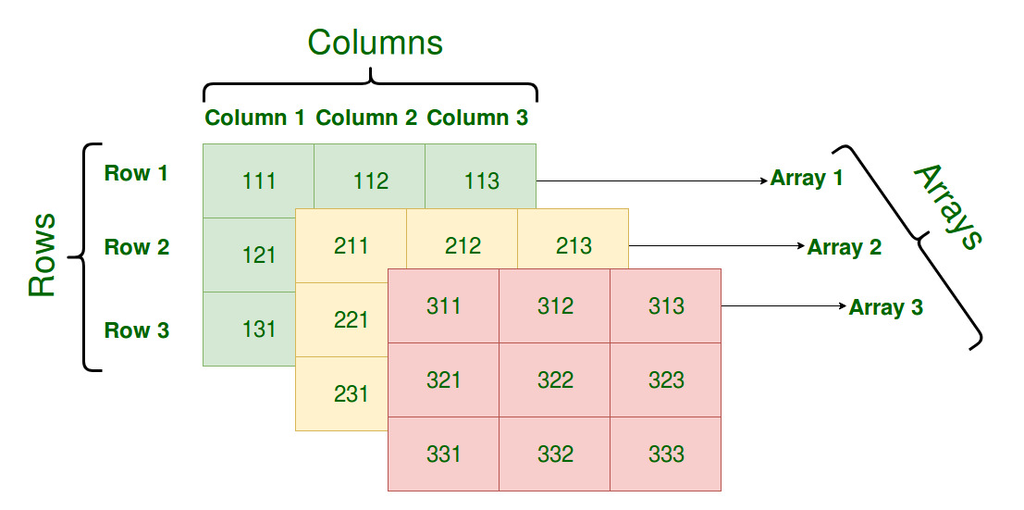

The general syntax for this function is `array(values you want to array, dim = (row, column, height))`.

### Data Structures - Lists

List objects can contain a series of the other objects we just learned about. A single list can contain a value, a vector, a matrix, AND a dataframe - or many of each!

How do I make a list?

Use the `list()` function!

## Selecting elements in a vector, matrix or data.frame

Sometimes we want to select single or multiple data entries from our objects. We can do this by selecting elements via `[]`.

Let’s first do it with a vector. Remember our country_code vector?

```r
country_code <- c("DE", "FR", "NL", "US", "UK")

country_code
```

Let’s say we only want to select the “US”. We can achieve this by accessing the value via its position in the vector:

```r
country_code[4]
```

Now we want to select all values but the “US”:

```r
country_code[-4]
```

You can pass multiple indexes as a vector:

```r
country_code[c(1, 2, 3)]
```

`1:3` generates the vector `c(1, 2, 3)` a bit quicker.

```r
country_code[1:3]
```

If we want the values “DE”, “FR”, and “US”, a sequence does not really help. But we can put a vector with a combination of a sequence and some other values in the square brackets:

```r
country_code[c(1:2, 4)]
```

#### Selecting items in two-dimensional objects

We can access values of a matrix similarly. However, we need to think of one additional dimension.

```r
example_mat <- matrix(c(1, 2, 3, 4, 5, 6),
                      nrow = 3,
                      ncol = 2)

example_mat
```

Generally, we type `object[row, column]` to access specific rows and columns. To see how this works, let’s have a look at our `example_mat`:

Now we want to access the value 6. It’s in the third row and the second column.

```r
example_mat[3, 2]
```

We could also select an entire column (and use it like a vector).

```r
example_mat[, 2]
```

```r
example_mat[, 1] <- 99

example_mat
```

```r
example_mat <- matrix(c(1, 2, 3, 4, 5, 6),
                      nrow = 3,
                      ncol = 2)

example_mat[, 1] <- 99
```

```r
# And we want to recode the first and the third value in the second column
# to 91 and 100

example_mat[c(1, 3), 2] <- c(91, 100)

example_mat
```

### Selection with conditions

This is a good start to select and recode data in an object. However, it might be a bit exhausting (maybe even impossible) to always look up the exact position in the object.

Luckily, R let’s us also select elements based on conditions. Instead of the position we put a condition in the [] square brackets.

- For this we can use several conditions:
  - Is equal to: `==`
  - Is not: `!=`
  - Is smaller than: `<`
  - Is greater than: `>`
  - Is smaller or equal to: `<=`
  - Is greater or equal to: `>=`
- Conditions can be combined with and and/or or statements
  - AND: `&`
  - OR: `|`

So how do conditions work? Let’s create a matrix to work with

```r
vec1 <- c(1, 2, 3, 4, 5, 6)

vec2 <- c(7, 8, 9, 10, 11, 12)

# And now column-bind (cbind()) the two vectors.

example_mat <- cbind(vec1, vec2)

example_mat
```

```r
example_mat > 9 # This returns TRUE or FALSE for each value in the object.
```

Now if we put this condition in square brackets we get the values for which the condition is true.

```r
example_mat[example_mat > 9]
```

### Exercise II: Selecting and recoding elements

Here comes the second round of exercises:

1. Create two vectors `vec1` and `vec2`.
   - `vec1` should contain 1, 56, 23, 89, -3 and 5 (in that order).
   - `vec2` contains 24, 78, 32, 27, 8 and 1.
2. Now select elements of `vec1` that are greater than 5 or smaller than 0.
3. Next set `vec1` to zero if `vec2` is greater than 30 and smaller or equal to 32.

## Working with data.frames

Working with data frames is similar to working with matrices and vectors.

### Loading and manipulating data

Usually (and especially for this class) we want to work with existing datasets. R knows and can load most of the standard formats of datasets, like `.csv`, `.xlsx` (Excel), `.dta` (Stata), `.sav` (SPSS) and many more.

So far we only used R’s base functions. In order to use some more sophisticated or special R functions, we need to load libraries or packages first. Think of these libraries as extra apps that you can load on your smartphones to extend its functionality.

Right now, we want to load the dataset. In order to use the standard but foreign datasets we need the *foreign* package.

First, we want to have a look at what the package can do.

```r
packageDescription("foreign")

# Ok this seems to be useful. So let's load the package to use it.
library(foreign)
```

You will often come across datasets which are stored as Stata data files. Those files have the extension `.dta`.

Right now, we want to load the data set called `weather_data_germany_2023.dta` which is already stored the `raw_data` folder in our directory:

```r
weather_data <- read.dta("raw_data/weather_data_germany_2023.dta")
```

The data contains yearly temperature averages of German cities as well as their geographical location (longitude and latitude). It comes from the “Deutscher Wetterdienst” and you can find it [here](https://cdc.dwd.de/portal/202204011005). Now that we have loaded the data, we can have a look at it.

With `head()`we can look at the first six rows of the data set:

```r
head(weather_data)
```

If we only want to look at the variable names, we can use `names()`:

```r
names(weather_data)
```

Now we can use our selecting abilities on a data frame. As before we can select elements via their numeric position:

```r
weather_data[1, 2] # first row, second column
```

```r
weather_data[1:3, 1] # rows 1-3, first column
```

Additionally, as columns usually have names in data frames, we can use the column names to select values in two ways.

First, we can put the column name in square brackets instead of a column number:

```r
weather_data[1, "city"]
```

Second, we can also select an entire column by using the `$` operator with the column name: `data.frame_name$column_name`. Just like this:

```r
weather_data$mean_temp
```

```
  [1] 11.14 12.28 11.37 10.22 11.32 11.12 10.73 11.12  9.07  9.83
 [11] 10.97 10.35 10.49 10.06 10.48 10.09  7.69 10.89 10.72 10.39
 [21] 11.70 10.56 12.43 11.26 12.13 10.13  9.90 11.71 10.52  9.95
 [31] 11.55 10.94  8.83 11.40 10.63 10.55 10.51 11.19  9.90 10.70
 [41]  9.67 12.31 11.44 10.69 10.69  9.83 11.29 10.35 10.10 11.60
 [51]  9.85 11.38 10.17  9.51 10.25  9.42 10.03 10.32  8.31 10.29
 [61]  9.50 11.41  9.73 10.79 10.69  9.40 10.08  7.88 10.26 11.35
 [71] 12.79 11.12 10.37  9.04  8.61 10.71 10.48 10.15 12.02  7.26
 [81] 11.72 10.60 11.10 10.01 10.39 10.34 10.52  8.52 11.59  7.12
 [91]  8.82 10.50 10.16 10.11  9.75 10.22 10.96 12.55 11.27 10.90
[101] 11.14 10.87 10.29 10.67 11.14 10.39 11.03  8.85 10.78  7.67
[111] 10.62 10.37 11.67 10.78 10.70 10.04  8.79 13.14  9.99 10.36
[121] 11.21 10.66 10.43 12.41 12.09 11.14 12.83 11.66 10.38 10.80
[131] 10.26 11.41 10.25 10.90 10.90  9.73 11.23 10.58  9.66 10.78
[141]  9.89 10.98 10.16 10.43 10.88 11.24 10.87 12.24  9.93  9.73
```

[output cut: 31 more lines]

Columns from data frames are essentially vectors. We can use all the operations and functions we can use for vectors (depending on their class.)

```r
weather_data$mean_temp[1] # For example, we can select an element of the vector
```

```
[1] 11.14
```

What if we want to add a new variable? Let’s create a variable named “cold”.

```r
weather_data$cold <- 0

# What does this do?

weather_data$cold
```

```
  [1] 0 0 0 0 0 0 0 0 0 0 0 0 0 0 0 0 0 0 0 0 0 0 0 0 0 0 0 0 0 0 0
 [32] 0 0 0 0 0 0 0 0 0 0 0 0 0 0 0 0 0 0 0 0 0 0 0 0 0 0 0 0 0 0 0
 [63] 0 0 0 0 0 0 0 0 0 0 0 0 0 0 0 0 0 0 0 0 0 0 0 0 0 0 0 0 0 0 0
 [94] 0 0 0 0 0 0 0 0 0 0 0 0 0 0 0 0 0 0 0 0 0 0 0 0 0 0 0 0 0 0 0
[125] 0 0 0 0 0 0 0 0 0 0 0 0 0 0 0 0 0 0 0 0 0 0 0 0 0 0 0 0 0 0 0
[156] 0 0 0 0 0 0 0 0 0 0 0 0 0 0 0 0 0 0 0 0 0 0 0 0 0 0 0 0 0 0 0
[187] 0 0 0 0 0 0 0 0 0 0 0 0 0 0 0 0 0 0 0 0 0 0 0 0 0 0 0 0 0 0 0
[218] 0 0 0 0 0 0 0 0 0 0 0 0 0 0 0 0 0 0 0 0 0 0 0 0 0 0 0 0 0 0 0
[249] 0 0 0 0 0 0 0 0 0 0 0 0 0 0 0 0 0 0 0 0 0 0 0 0 0 0 0 0 0 0 0
[280] 0 0 0 0 0 0 0 0 0 0 0 0 0 0 0 0 0 0 0 0 0 0 0 0 0 0 0 0 0 0 0
[311] 0 0 0 0 0 0 0 0 0 0 0 0 0 0 0 0 0 0 0 0 0 0 0 0 0 0 0 0 0 0 0
[342] 0 0 0 0 0 0 0 0 0 0 0 0 0 0 0 0 0 0 0 0 0 0 0 0 0 0 0 0 0 0 0
[373] 0 0 0 0 0 0 0 0 0 0 0 0 0 0 0 0 0 0 0 0 0 0 0 0 0 0 0 0 0 0 0
[404] 0 0 0 0 0 0 0 0 0 0 0 0 0 0 0 0 0 0 0 0 0 0 0 0 0 0 0 0 0 0 0
[435] 0 0 0 0 0 0 0 0 0 0 0 0 0 0 0 0 0 0 0 0
```

[output not shown]

[output cut: 444 more lines]

## Calculating Measures of Central Tendency and Variability

Let’s look at the Measures of Central Tendency and Variability from the lecture (starting at slide 17).

How could we calculate the mean of `example_vec`?

We could simply calculate it “by hand”:

```r
(1 + 2 + 3 + 4 + 5) / 5
```

```
[1] 3
```

But this is not very useful if we look at an actual vector in our data frame, e.g., mean temperature:

```r
weather_data$mean_temp
```

```
  [1] 11.14 12.28 11.37 10.22 11.32 11.12 10.73 11.12  9.07  9.83
 [11] 10.97 10.35 10.49 10.06 10.48 10.09  7.69 10.89 10.72 10.39
 [21] 11.70 10.56 12.43 11.26 12.13 10.13  9.90 11.71 10.52  9.95
 [31] 11.55 10.94  8.83 11.40 10.63 10.55 10.51 11.19  9.90 10.70
 [41]  9.67 12.31 11.44 10.69 10.69  9.83 11.29 10.35 10.10 11.60
 [51]  9.85 11.38 10.17  9.51 10.25  9.42 10.03 10.32  8.31 10.29
 [61]  9.50 11.41  9.73 10.79 10.69  9.40 10.08  7.88 10.26 11.35
 [71] 12.79 11.12 10.37  9.04  8.61 10.71 10.48 10.15 12.02  7.26
 [81] 11.72 10.60 11.10 10.01 10.39 10.34 10.52  8.52 11.59  7.12
 [91]  8.82 10.50 10.16 10.11  9.75 10.22 10.96 12.55 11.27 10.90
[101] 11.14 10.87 10.29 10.67 11.14 10.39 11.03  8.85 10.78  7.67
[111] 10.62 10.37 11.67 10.78 10.70 10.04  8.79 13.14  9.99 10.36
[121] 11.21 10.66 10.43 12.41 12.09 11.14 12.83 11.66 10.38 10.80
[131] 10.26 11.41 10.25 10.90 10.90  9.73 11.23 10.58  9.66 10.78
[141]  9.89 10.98 10.16 10.43 10.88 11.24 10.87 12.24  9.93  9.73
```

[output cut: 31 more lines]

Typing up all the entries individually would take a lot of time. We could use two functions that we already have seen, sum and length.

```r
sum(weather_data$mean_temp) / length(weather_data$mean_temp)
```

```
[1] 10.56586
```

Fortunately, R provides a much easier way to calculate a mean:

```r
mean(weather_data$mean_temp) # That was easy.
```

```
[1] 10.56586
```

But be sure that your vector is numeric. Could you calculate the mean of city?

```r
weather_data$city
```

Let’s try to calculate the mean.

```r
mean(weather_data$city)
```

```
[1] NA
```

It does not work! And even by hand we could not calculate the mean of character valued vectors.

Here is an overview over functions for measures of centrality and variability:

- Mean: `mean()`
- Median: `median()`
- Variance: `var()`
- Standard Deviation: `sd()`
- Range: `range()`
- Inter-quartile range: `IQR()`

You can try them out here:

```r
IQR(weather_data$mean_temp)
```

```
[1] 1.015
```

Unfortunately, there is no direct function to get the mode. The solutions you will find online are all a bit advanced. So the easiest solution is to look for the mode using a frequency table.

```r
table(weather_data$cold)
```

[output not shown]

The `table()` function shows you how often each value is in the vector. You can now identify the most frequent value.

### Exercise III: Manipulating data

Now we will work with the `weather_data` data set. It is already loaded for you and you can use it right away.

1. Show the variable `mean_temp` if it is over 10.
2. Generate a new variable and call it `hot` that is zero for *mean temperature* < 10 and 1 for *mean temperature* > 10 degree Celsius.
3. Have a look at your data set.

### Exercise V: Measures of central tendency

We will continue working with the weather data set

1. Calculate the mean value of latitude and save the result as `mean_latitude`.
2. Calculate the variance of latitude and save the result as `var_latitude`.
3. Calculate the standard deviation of latitude and save the result as `sd_latitude`.

## Plotting data

Let’s have a short look at our data again. Remember: `head()` shows you the first six entries of your data. It is very useful to get a look at the data structure when you have a lot of rows in your dataset.

```r
head(weather_data)
```

### Plots for bivariate distributions

#### Scatterplots

Now we can create a simple scatterplot:

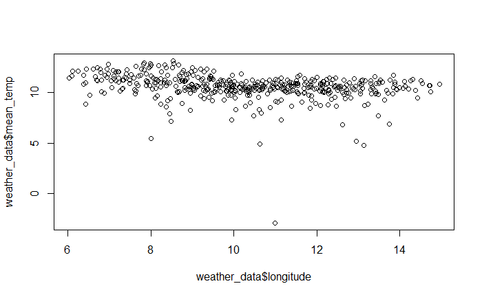

```r
plot(
  x = weather_data$longitude,
  y = weather_data$mean_temp
)
```

To get a nicer plot, we can adjust many things. We suggest to always explicitly make those adjustments in the same order.

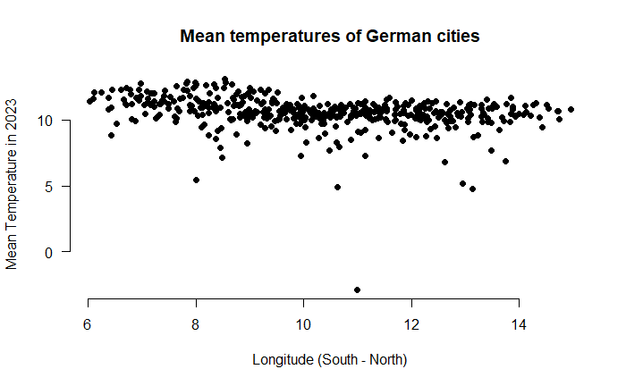

```r
plot(
  x = weather_data$longitude,
  y = weather_data$mean_temp,
  type = "p", # This explicitly says that we want points. You could also try "l".
  main = "Mean temperatures of German cities", # This adds a title to the plot
  xlab = "Longitude (South - North)", # This labels the x-axis.
  ylab = "Mean Temperature in 2023", # What does this do then?
  las = 1, # This affects the tick labels of the y-axis.
  pch = 19, # Here we choose what symbols we want to plot.
  col = "black", # What color should the symbols have?
  frame = F # No box around the plot.
)
```

### Adding Color to Plots with Viridis

We can also adjust the colors. Let’s highlight Mannheim!

> Pro Tip: To color up your data visualizations, use the [viridis-package](https://cran.r-project.org/web/packages/viridis/vignettes/intro-to-viridis.html).

Viridis colors make it easier to read by those with colorblindness and print well in greyscale. You probably don’t want to have plots like this:

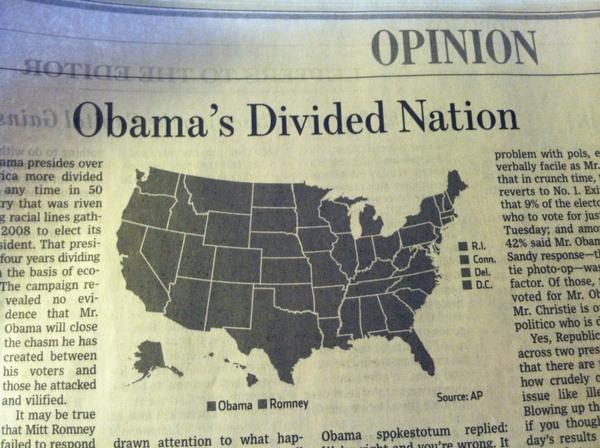

We first need a vector that gives us the right colors with respect to the city variable.

```r
library(viridis)
# we need two colors, this is how we get them:
two_colors <- viridis(2)

two_colors # these are so-called HEX color codes
```

```
[1] "#440154FF" "#FDE725FF"
```

```r
# we use the first color for males and the second for females
mannheim_color <- ifelse(weather_data$city == "Mannheim", two_colors[1], two_colors[2])

# let's have a look:
table(mannheim_color)
```

```
mannheim_color
#440154FF #FDE725FF
        1       453
```

Now we can use this vector to specify the color respective to Mannheim:

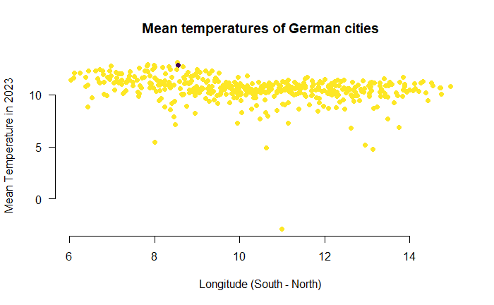

```r
plot(
  x = weather_data$longitude,
  y = weather_data$mean_temp,
  type = "p", # This explicitly says that we want points. You could also try "l".
  main = "Mean temperatures of German cities", # This adds a title to the plot
  xlab = "Longitude (South - North)", # This labels the x-axis.
  ylab = "Mean Temperature in 2023", # What does this do then?
  las = 1, # This affects the tick labels of the y-axis.
  pch = 19, # Here we choose what symbols we want to plot.
  col = mannheim_color, # Instead of just black we now use the color vector.
  frame = F # No frame around the plot.
)
```

Now that we use different colors, we also need a legend to know which color is which.

```r
plot(
  x = weather_data$longitude,
  y = weather_data$mean_temp,
  type = "p", # This explicitly says that we want points. You could also try "l".
  main = "Mean temperatures of German cities", # This adds a title to the plot
  xlab = "Longitude (South - North)", # This labels the x-axis.
  ylab = "Mean Temperature in 2023", # What does this do then?
  las = 1, # This affects the tick labels of the y-axis.
  pch = 19, # Here we choose what symbols we want to plot.
  col = mannheim_color, # Instead of just black we now use the color vector.
  frame = F # No frame around the plot.
)
legend(
  "bottomleft", # Locate the legend in the topleft corner.
  legend = c("Mannheim", "other"), # Give it labels.
  pch = 19, # Specify symbols as in the scatterplot.
  col = two_colors, # Specify colors.
  bty = "n" # No box around the legend.
)
```

[output not shown]

```r
plot(
  x = weather_data$longitude,
  y = weather_data$mean_temp,
  type = "p", # This explicitly says that we want points. You could also try "l".
  main = "Mean temperatures of German cities", # This adds a title to the plot
  xlab = "Longitude (South - North)", # This labels the x-axis.
  ylab = "Mean Temperature in 2023", # What does this do then?
  las = 1, # This affects the tick labels of the y-axis.
  pch = 19, # Here we choose what symbols we want to plot.
  col = mannheim_color, # Instead of just black we now use the color vector.
  frame = F # No frame around the plot.
)
# we want to label the point that refers to Mannheim
# We can do that with the text() function,
# But we need to subset the data, so that only Mannheim gets labelled,
# and no other city
text(
  x = weather_data$longitude[weather_data$city == "Mannheim"], # subset Mannheim
  y = weather_data$mean_temp[weather_data$city == "Mannheim"], # subset Mannheim
  labels = "Mannheim", # label Mannheim as "Mannheim"
  pos = 4 # position the label right to the point
)
```

[output not shown]

### Plots for univariate distributions

#### Histograms

Now we want to visualize mean temperature with a histogram. This is how you get a standard histogram:

```r
hist(x = weather_data$mean_temp) # That's intuitive, but does not look too great
```

[output not shown]

Again, we can adjust many things to make it nicer.

```r
hist(
  x = weather_data$mean_temp, # For a histogram we only specify x.
  breaks = 50, # specify the number of bins
  main = "A Histogram",
  xlab = "Mean temperature in degree Celsius",
  ylab = "Number of observations",
  las = 1, # shift the y-axis labels
  col = viridis(1), # One color only (first color from viridis)
  border = "white" # That's the color of the bin borders.
)
```

[output not shown]

#### Density Plots

We can also create density plots.

```r
plot(
  density(weather_data$mean_temp), # density() takes care of x, y and type.
  main = "A Simple Density Plot",
  xlab = "Mean temperature in degree Celsius",
  ylab = "", # The y-axis is not really meaningful here.
  col = viridis(1),
  lwd = 2, # Control the width of the line
  frame = F,
  yaxt = "n" # Remove the y-axis.
)
```

[output not shown]

And we can also fill the are underneath the curve:

```r
plot(
  density(weather_data$mean_temp), # density() takes care of x, y and type.
  main = "A Simple Density Plot",
  xlab = "Mean temperature in degree Celsius",
  ylab = "", # The y-axis is not really meaningful here.
  col = viridis(1),
  lwd = 2, # Control the width of the line
  frame = F,
  yaxt = "n" # Remove the y-axis.
)

polygon(density(weather_data$mean_temp),
        col = viridis(1, alpha = 0.5) # same color but 50% transparent
        )
```

[output not shown]

#### …and Boxplots

```r
boxplot(
  x = weather_data$mean_temp, # As for histograms we only specify x.
  main = "Boxplot of Mean temperature in degree Celsius",
  ylab = "Mean temperature in degree Celsius",
  las = 1,
  col = plasma(1),
  frame = F
)
```

[output not shown]

Or a horizontal boxplot.

```r
boxplot(
  x = weather_data$mean_temp,
  horizontal = T, # With horizontal = T we rotate the boxplot.
  main = "Horizontal Boxplot of Mean temperature in degree Celsius",
  xlab = "Mean temperature in degree Celsius",
  las = 1,
  frame = F
)
```

[output not shown]

You learned in the lecture that boxplots have some disadvantages.

> Violin plots are a very nice alternative!

This is how you get them:

```r
library(vioplot)

vioplot(
  x = weather_data$mean_temp,
  horizontal = T, # With horizontal = T we rotate the boxplot.
  main = "Horizontal Violinplot of Mean temperature in degree Celsius",
  xaxt = "n",
  xlab = "Mean temperature in degree Celsius",
  bty = "n",
  axes = FALSE,
  names = "",
  border = NA
)
```

[output not shown]

### Exercise VI: Plotting

Okay, last round of exercises for today:

1. Make a histogram of the *latitude* variable.
2. Make the plot nice looking (Name the axes, main title, colors…)

## Recap

What we learned in this session:

1. How to work with R and GitHub.
2. Assigning objects in R.
3. Different data structures in R.
4. How to get to single elements within data structures.
5. Working with data frames.
6. How to load a data set into R.
7. How to make nice looking plots in R.

## What you will do in your homework.

The first lab session and this script should equip you with all the tools (and lines of code) to tackle the first homework assignment.

> Copy the lines of code that worked for something similar. Then, adjust the code according to your problem.

Substantially, in your homework you will inspect a data set on US presidential elections. You will calculate some measures of central tendency and variability. Finally, you will produce some nice plots.

It is best to get started with your homework as soon as possible (after it was handed out on Friday).

Try to write the R Code first. We will provide you a `.Rmd` template to hand in your results.

In order to pass the homework assignment you need to tackle ALL problems of a problem set. For a pass you also need to get most of the problems right (or at least show us that you tried everything to get it right.)

### Closing remarks.

If you have any questions concerning the lecture or the tutorial please post them on Slack. We will answer them on a regular basis.

Do not hesitate to come to the office hours!

And always remember if you have a question, it is never a stupid question. In fact most of your fellow students probably have the same or a similar question. By asking it, everyone in this class will profit.